# Bringing Bus Stops and Pantries Closer

People who need to get food from food pantries do not always have reliable personal vehicles. Are they able to get to the food pantries by using public transportation?

#### Can people get to food pantries by bus?

We visualized locations of food pantries and bus stops in the four counties Durham, Johnston, Orange, and Wake. Our analysis shows which pantries have bus stops within a mile (a ‘reasonable’ walking distance) of their location.

Limitations: The distance between pantries and bus stops is calculated as great circle distance. Obstacles which might increase the actual walking distance (such as rivers, buildings, walls) were not taken into account. We emphasize that this analysis does not ask whether there are bus routes from low income areas to food pantries. This analysis only addresses whether it is possible for someone somewhere to travel to pantries in Wake, Durham, Orange and Johnston counties by bus. Another limitation is that we are missing bus schedules (to determine which days/hours a bus operates) and hours for food pantries.

#### Visualization

The locations of food pantries and bus stops (GoTriangle, GoRaleigh, GoDurham, Chapel Hill Transit, NC State University Wolfline, Duke University Transit) in the four counties Durham, Johnston, Orange, and Wake:  
Note that Johnston County does not have bus lines except for limited use by handicapped and elderly people. Including Johnston County there are 169 food pantries, excluding Johnston County there are 136 pantries.

[interactive chart not shown]

How close is each pantry to the nearest bus stop?

Johnston county has the most room for improvement (since there is no public transportation), but lower cost improvement might be in Wake county where there are existing bus lines that could be extended or modified.

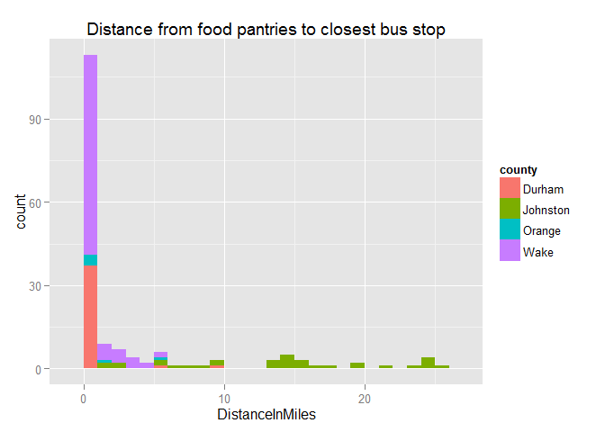

[interactive chart not shown]

Limitations:  
We have merely looked at pantries that have bus stops within less than a mile. Future analyses should address whether there are bus routes that travel from low income neighborhoods (e.g., by zip codes identified as low income) to the food pantries in a reasonable amount of time (e.g., less than 1 hour).

#### Sources

[TransLoc](https://mashape.com/transloc/openapi-1-2)  
[NC 2-1-1 Community Resource Database](http://www.nc211.org/index.php/find-help)

Files used for the analysis (downloaded Oct/Nov 2015):  
A list of food pantries pantries.csv  
A list of bus stops [bustops.rds](https://raw.githubusercontent.com/DrZeydy/Data4Good/gh-pages/busstops.rds)  
A list of bus transportation agencies local_agencies.csv

#### Contributors

Monika Sanghi  
Kip Sutter  
Clara Sutter  
Rex Dwyer  
Alice Broadhead  
Lucia Gjeltema